# CreativeAssignmentTwo

Whytne Stevens

9/18/2020

For this creative assignment, I was interested in looking at urban areas on the African continent. First I loaded relevant r libraries and pulled a world map using the libraries loaded below.

```r
library(ggplot2)
library(sf)
library(rnaturalearth)
library(tidyverse)
library(ggspatial)
library(cartogram)
library(ggthemes)
library(rgeos)
library(packcircles)
library(viridis)
library(wesanderson)
```

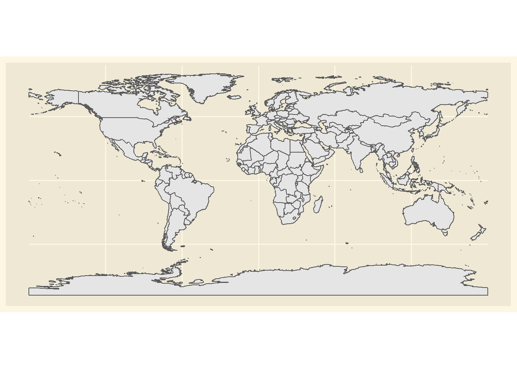

```r
world <- ne_countries(scale = 50, returnclass = "sf")

world_map <- ggplot(world) +
  geom_sf() +
  theme_solarized_2()

world_map
```

# Experimenting with Map Projections of Africa

I then pulled a map of the African continent with country boundaries drawn on the map.

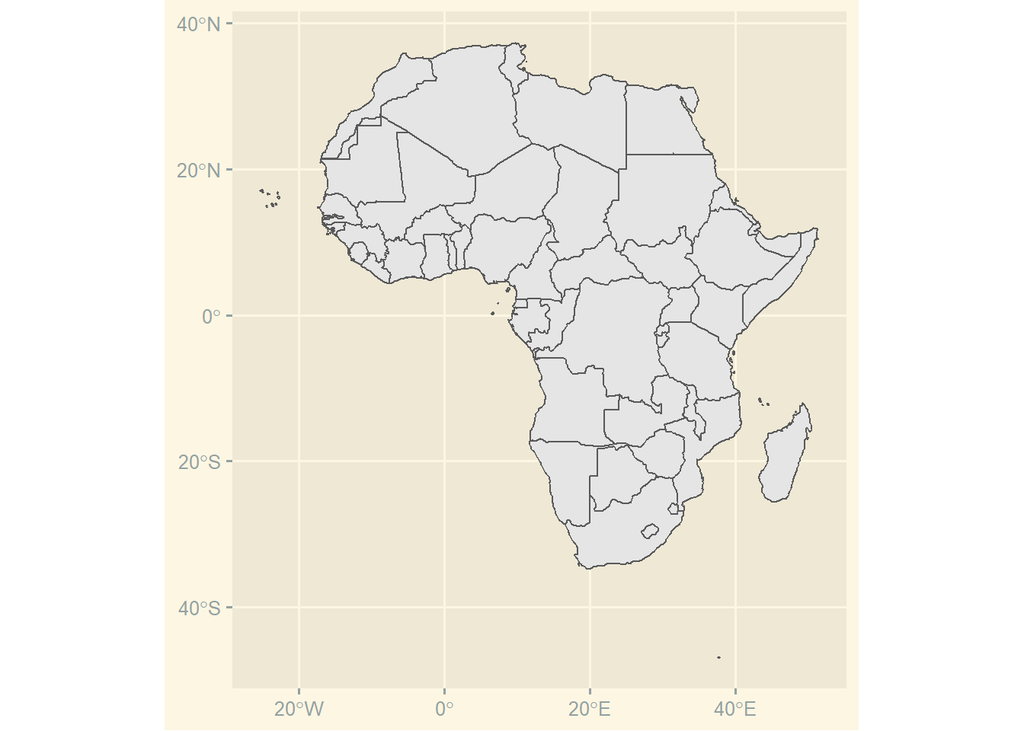

```r
africa_countries <- world %>%
  filter(continent == "Africa")

africa_map <- ggplot(africa_countries) +
  geom_sf() +
  theme_solarized_2()

africa_map
```

And added a scale bar as well.

```r
africa_map +
  annotation_scale()
```

```
## Scale on map varies by more than 10%, scale bar may be inaccurate
```

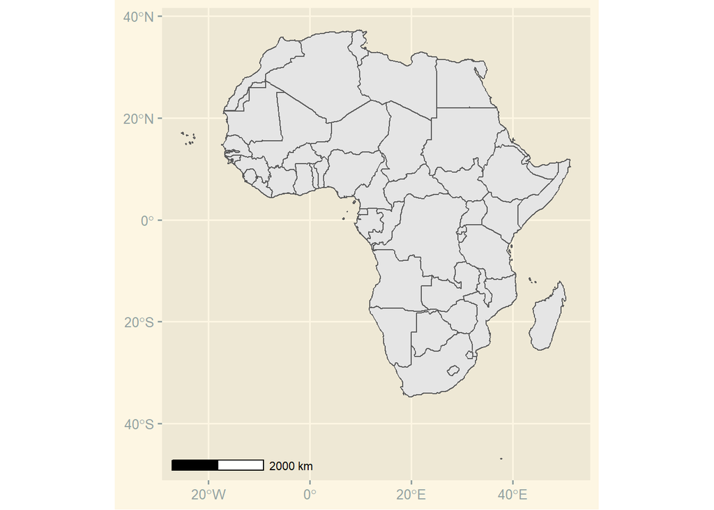

Next I defined my coordinate systems. I wanted to experiment with a variety of coordinate systems for my projections, so I pulled some oriented on the African continent, some oriented on former colonizing countries such as France, and some oriented on Asian countries such as Japan.

```r
Africa_AEA_Conic <- "+proj=aea +lat_1=20 +lat_2=-23 +lat_0=0 +lon_0=25 +x_0=0 +y_0=0 +ellps=WGS84 +datum=WGS84 +units=m +no_defs"
Abidjan_1987 <- "+proj=longlat +ellps=clrk80 +towgs84=-124.76,53,466.79,0,0,0,0 +no_defs"
East_Africa <- "+proj=utm +zone=36 +south +ellps=clrk80 +units=m +no_defs"
North_African_Bonne <- "+proj=bonne +lon_0=2.337208 +lat_1=35.1 +x_0=0 +y_0=0 +a=6378249.2 +b=6356514.999904194 +units=m +no_defs"
Test_French_West_Africa_Niger_zone <- "+proj=tmerc +lat_0=0 +lon_0=7.3 +k=0.999 +x_0=1000000 +y_0=1000000 +ellps=WGS84 +datum=WGS84 +units=m +no_defs"
Africa_Sinusoidal <- "+proj=sinu +lon_0=0 +x_0=0 +y_0=0 +ellps=WGS84 +datum=WGS84 +units=m +no_defs"
Africa_Equidistant_Conic <- "+proj=eqdc +lat_0=0 +lon_0=0 +lat_1=20 +lat_2=-23 +x_0=0 +y_0=0 +ellps=WGS84 +datum=WGS84 +units=m +no_defs "
Africa_Lambert_Conformal_Conic <- "+proj=lcc +lat_1=20 +lat_2=-23 +lat_0=0 +lon_0=25 +x_0=0 +y_0=0 +ellps=WGS84 +datum=WGS84 +units=m +no_defs"
brads <- "+proj=tmerc +lat_0=0 +lon_0=31 +k=1 +x_0=0 +y_0=0 +ellps=WGS84 +units=m +no_defs"
france <- "+proj=lcc +lat_1=46.8 +lat_0=46.8 +lon_0=2.337229166666663 +k_0=0.99987742 +x_0=600000 +y_0=2200000 +a=6378249.2 +b=6356515.000000472 +units=m +no_defs"
NTF_France_III_degrees <- "+proj=lcc +lat_1=44.1 +lat_0=44.1 +lon_0=2.337229166666667 +k_0=0.999877499 +x_0=600000 +y_0=3200000 +a=6378249.2 +b=6356514.999904194 +units=m +no_defs"
Brazil <- "+proj=longlat +ellps=GRS80 +no_defs"
SAD69_Brazil <- "+proj=poly +lat_0=0 +lon_0=-54 +x_0=0 +y_0=0 +ellps=aust_SA +units=m +no_defs"
Ba <- "+proj=poly +lat_0=0 +lon_0=-54 +x_0=0 +y_0=0 +ellps=aust_SA +units=m +no_defs"
Japan_Plane_Rectangular_CS_V <- "+proj=tmerc +lat_0=36 +lon_0=134.3333333333333 +k=0.9999 +x_0=0 +y_0=0 +ellps=GRS80 +towgs84=0,0,0,0,0,0,0 +units=m +no_defs"
Pusan_CRS <- "+proj=tmerc +lat_0=40 +lon_0=140.8333333333333 +k=0.9999 +x_0=0 +y_0=0 +ellps=GRS80 +towgs84=0,0,0,0,0,0,0 +units=m +no_defs "
```

## Minimally Distorted Map Projections of Africa

As you can see, the ones based on Africa are more or less “normal”, with minimal distortion:

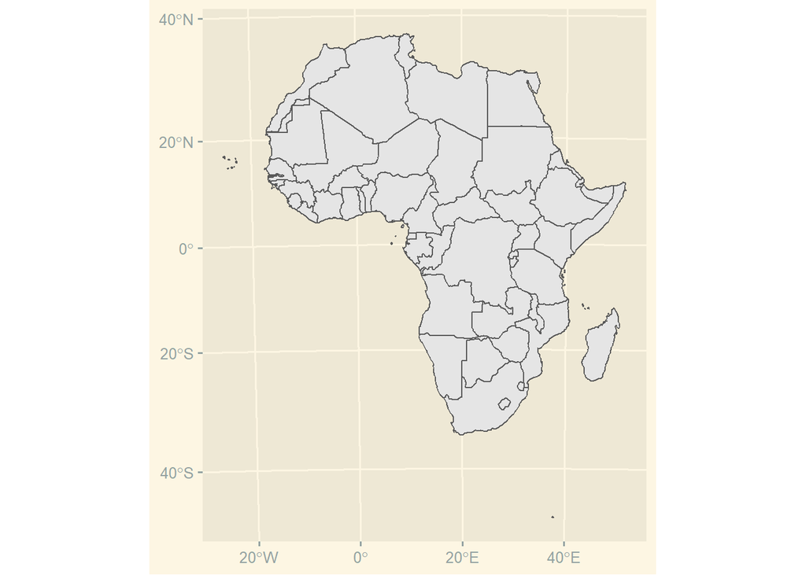

```r
africa_map +
  geom_sf() +
  coord_sf(crs = Africa_Lambert_Conformal_Conic) +
  theme_solarized_2()
```

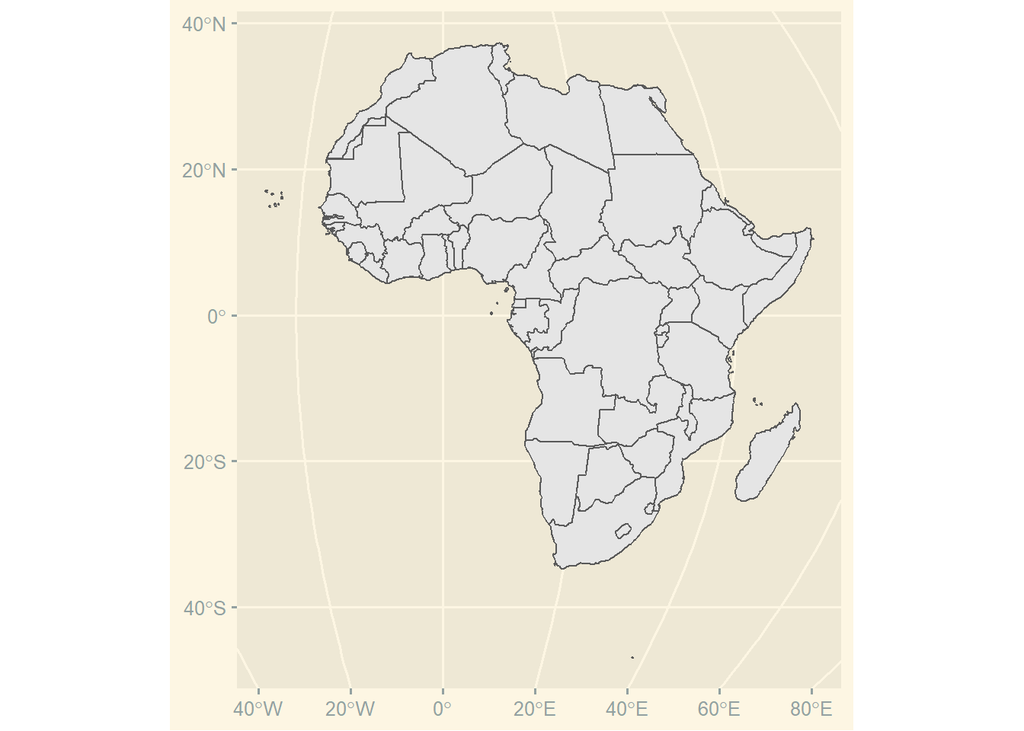

```r
africa_map +
  geom_sf() +
  coord_sf(crs = Africa_Sinusoidal) +
  theme_solarized_2()
```

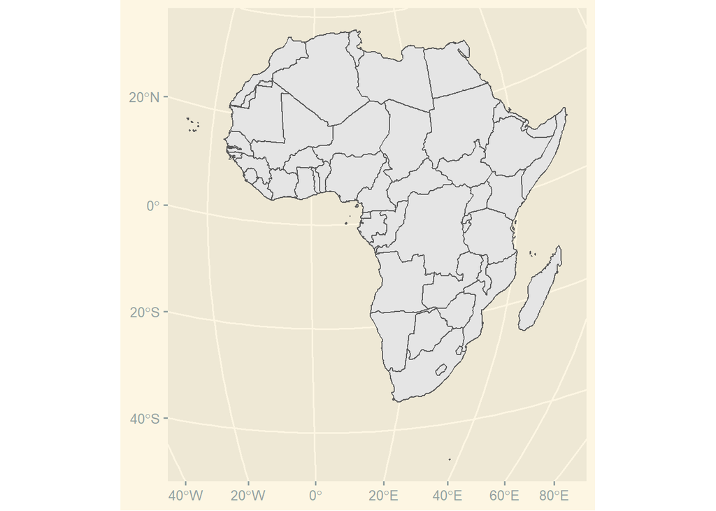

```r
africa_map +
  geom_sf() +
  coord_sf(crs = North_African_Bonne) +
  theme_solarized_2()
```

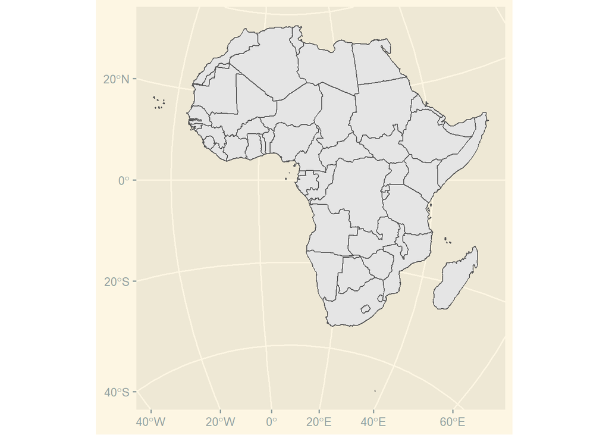

```r
africa_map +
  geom_sf() +
  coord_sf(crs = Test_French_West_Africa_Niger_zone) +
  theme_solarized_2()
```

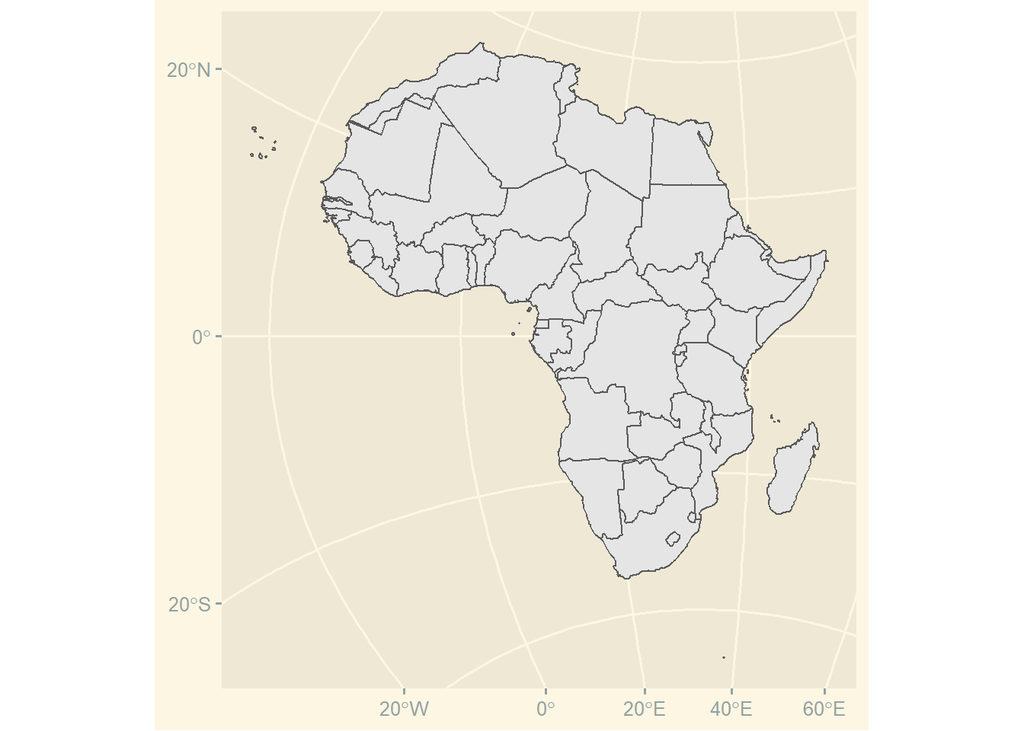

```r
africa_map +
  geom_sf() +
  coord_sf(crs = East_Africa) +
  theme_solarized_2()
```

## Heavily Distorted Map Projections of Africa

On the other hand, the coordinate systems not based in Africa produced some very interesting results:

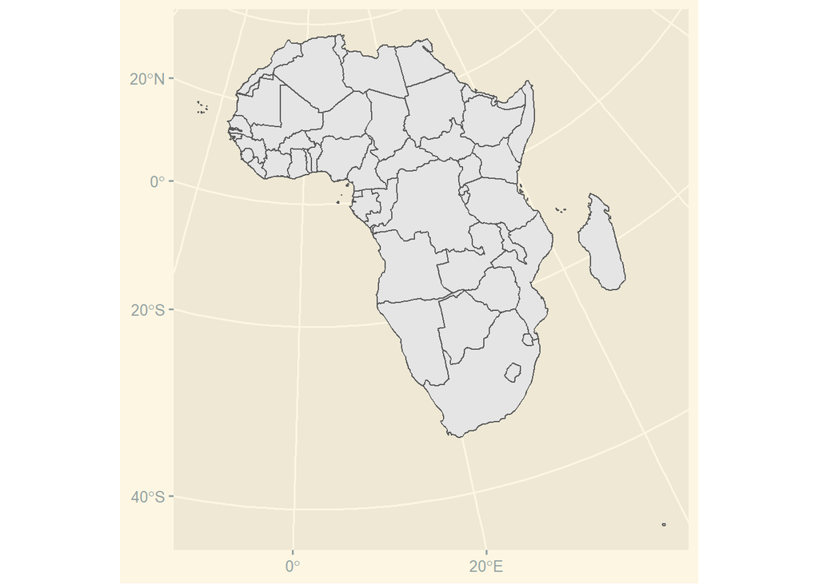

```r
africa_map +
  geom_sf() +
  coord_sf(crs = NTF_France_III_degrees) +
  theme_solarized_2()
```

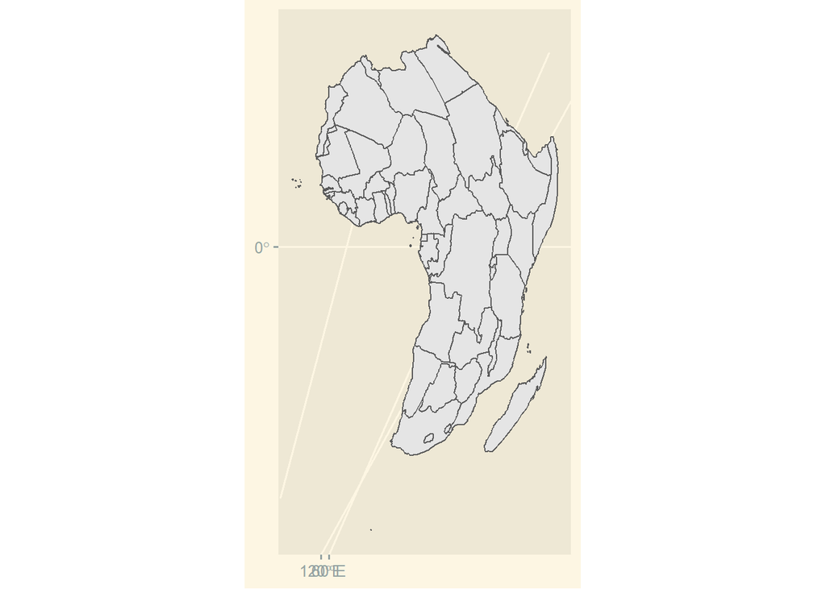

```r
africa_map +
  geom_sf() +
  coord_sf(crs = SAD69_Brazil) +
  theme_solarized_2()
```

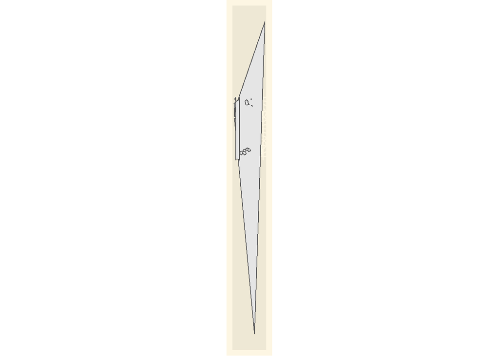

```r
africa_map +
  geom_sf() +
  coord_sf(crs = Japan_Plane_Rectangular_CS_V) +
  theme_solarized_2()
```

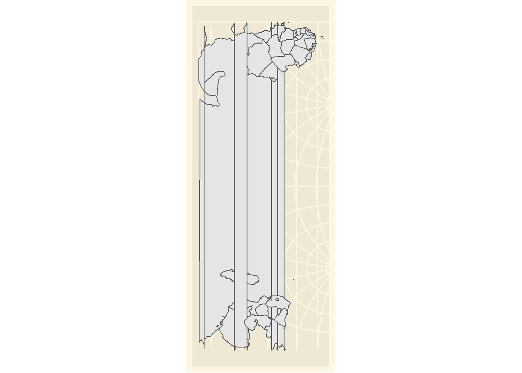

```r
africa_map +
  geom_sf() +
  coord_sf(crs = Pusan_CRS) +
  theme_solarized_2()
```

# Setting Up Map and Dataset for Visualizing Urbanization in Africa

After experimenting with different coordinate systems for my projections, I chose to use the Africa Lambert Conformal Conic coordinate system, using this to transform my original Africa map (africa_countries).

```r
africa_countries_transformed <- africa_countries %>%
  st_transform(crs = Africa_Lambert_Conformal_Conic)
```

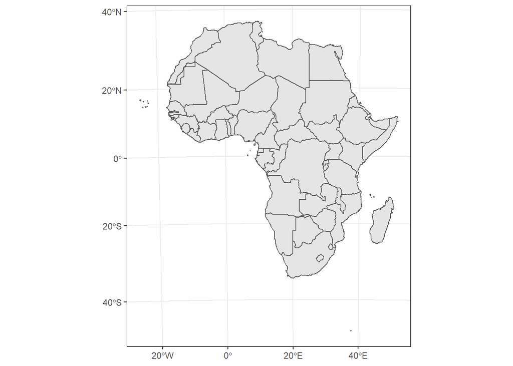

```r
ggplot(africa_countries_transformed) +
  geom_sf() +
  theme_bw()
```

## Data Wrangling

Having pulled these projections, I then pulled data on the urban areas in Africa. For my analysis I created my own dataset using data provided from Africapolis.org, a project created by the Sahel and West Africa Club (SWAC) (which has ties to the Organisation for Economic Co-operation and Development (OECD)) and e-geopolis.org (link: https://africapolis.org/data ). From this dataset, I am using the total urban population of each country to define and measure urbanization in African countries. I also had to mutate my data as some of the country names on my urban_africa dataset were not matching up with the other dataset (urban_africa_countries) I pulled using some of the r libraries I loaded.

```r
urban_africa <- read_csv("africa_urbanization.csv")%>%
  rename(upop15= "UrbanPopulation2015")%>%
  mutate(Country= ifelse(Country=="Central African Republic","Central African Rep.", Country))%>%
  mutate(Country= ifelse(Country=="Kingdom of Eswatini","Swaziland", Country))%>%
  mutate(Country= ifelse(Country=="Cabo Verde","Cape Verde", Country))%>%
  mutate(Country= ifelse(Country=="Republic of the Congo","Congo", Country))%>%
  mutate(Country= ifelse(Country=="Democratic Republic of the Congo","Dem. Rep. Congo", Country))%>%
  mutate(Country= ifelse(Country=="Cote d`Ivoire","Côte d'Ivoire", Country))%>%
  mutate(Country= ifelse(Country=="Equatorial Guinea","Eq. Guinea", Country))%>%
  mutate(Country= ifelse(Country=="The Gambia","Gambia", Country))%>%
  mutate(Country= ifelse(Country=="South Sudan","S. Sudan", Country))%>%
  mutate(Country= ifelse(Country=="Sao Tome and Principe","São Tomé and Principe", Country))


urban_africa_countries <-africa_countries_transformed %>%
  left_join(urban_africa, by = c("name" = "Country")) %>%
  select(name, upop15)
```

# Visualizing Urbanization in Africa

After setting up the and dataset I wanted to use for this assignment, I was then able to create the following maps and cartograms to visualize my data. Even with my data wrangling however, I still wasn’t able to account for four of the countries/regions: Comoros, Madagascar, Somaliland, and Western Sahara. There’s a few explanations for some of these - Somaliland is a self declared state in Somalia but is not fully recognized internationally and therefore is not a fully sovereign state, and Western Sahara is a disputed territory in Morocco also not fully recognized internationally and therefore is not a fully sovereign state.

As for Comoros and Madagascar, these countries weren’t included in the original dataset from Africapolis.org and the reasoning for this is unknown. I also noticed that Seychelles, another African country was not included in either the Africapolis.org data set or the one in the r libraries. Thus, Comoros, Madagascar, Somaliland, and Western Sahara are either grayed out or blank on the maps/cartograms below.

## Chloropleth Map

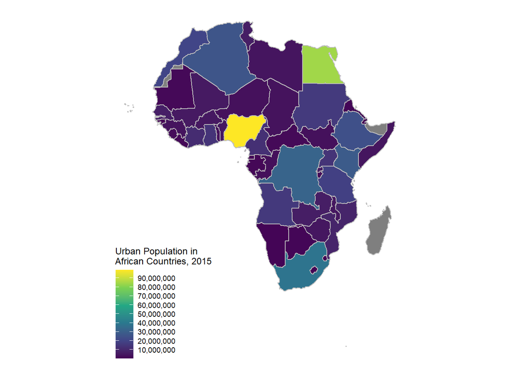

```r
ggplot(urban_africa_countries, aes(fill = upop15)) +
  geom_sf(color = "gray") +
  scale_fill_viridis_c(
    name = "Urban Population in\nAfrican Countries, 2015",
    breaks = seq(0, 100000000, by = 10000000),
    labels = formatC(seq(0, 100000000, by = 10000000),
                     big.mark = ",", format = "f", digits = 0),
    option =) +
  theme_map() +
  theme(legend.background = element_blank())
```

After class today (23 September ’20), I decided to experiment more with colors and was finally able to get the wesanderson color palettes to work. Even though the Royal1 palette does use red, it also offered more color differentiation which allows for the countries in the middle range of my data set to be more visible in the visualizations.

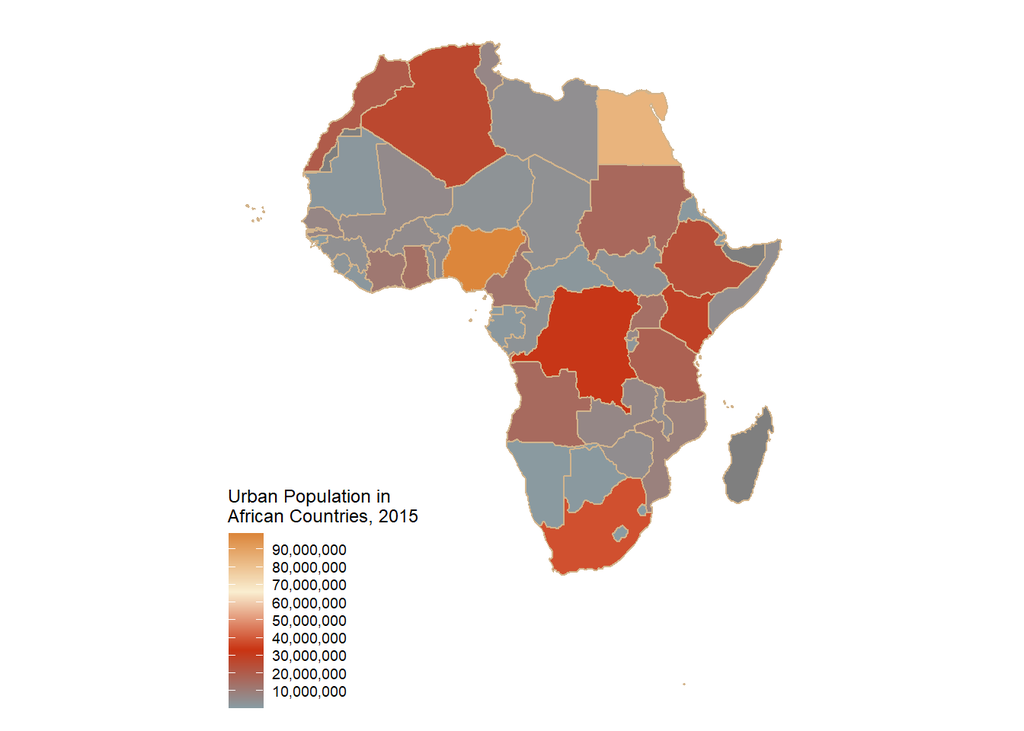

```r
pal <- wes_palette("Royal1", 100, type = "continuous")

ggplot(urban_africa_countries, aes(fill = upop15)) +
  geom_sf(color = "tan") +
  scale_fill_gradientn(
    name = "Urban Population in\nAfrican Countries, 2015",
    breaks = seq(0, 100000000, by = 10000000),
    labels = formatC(seq(0, 100000000, by = 10000000),
                     big.mark = ",", format = "f", digits = 0),
    colors = pal) +
  theme_map() +
  theme(legend.background = element_blank())
```

## Continuous Cartogram

```r
urban_africa_cartogram_cont <- urban_africa_countries %>%
  cartogram_cont("upop15")
```

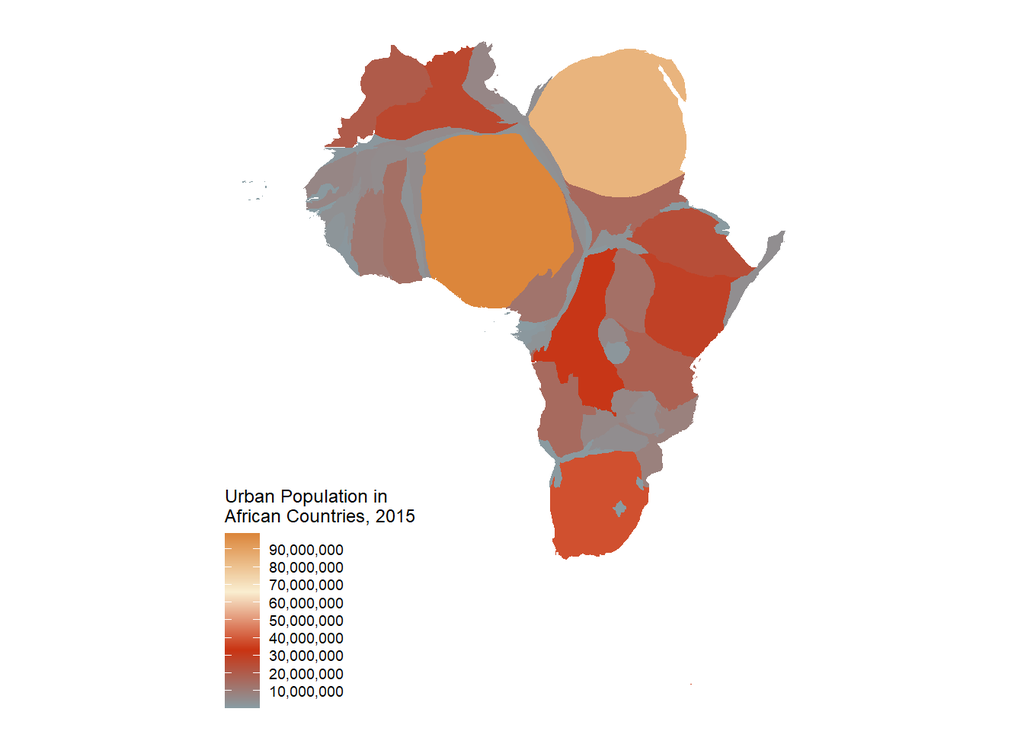

```r
ggplot(urban_africa_cartogram_cont, aes(fill = upop15)) +
geom_sf(color = NA) +
  scale_fill_gradientn(
    name = "Urban Population in\nAfrican Countries, 2015",
    breaks = seq(0, 100000000, by = 10000000),
    labels = formatC(seq(0, 100000000, by = 10000000),
                     big.mark = ",", format = "f", digits = 0),
    colors = pal) +
  theme_map() +
  theme(legend.background = element_blank())
```

## Non-Continuous Cartogram

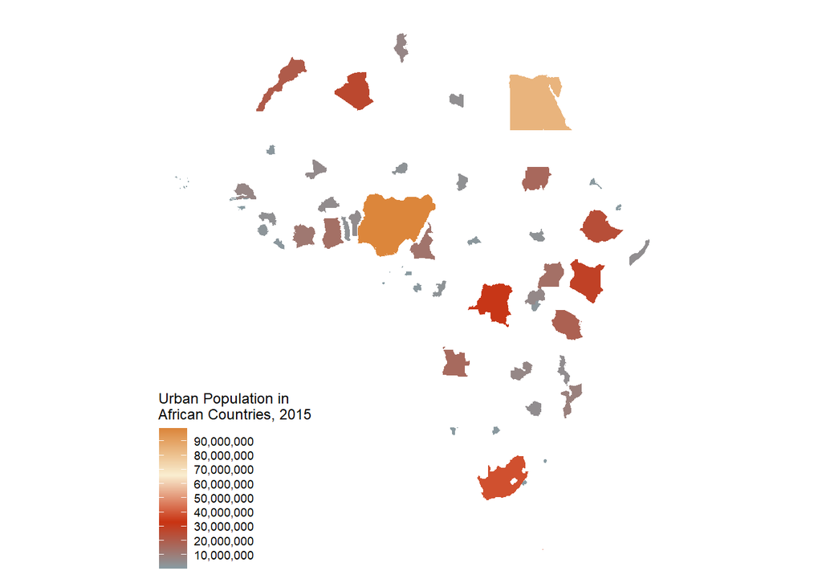

```r
urban_africa_cartogram_ncont <- urban_africa_countries %>%
  cartogram_ncont("upop15")

ggplot(urban_africa_cartogram_ncont, aes(fill = upop15)) +
geom_sf(color = NA) +
    scale_fill_gradientn(
    name = "Urban Population in\nAfrican Countries, 2015",
    breaks = seq(0, 100000000, by = 10000000),
    labels = formatC(seq(0, 100000000, by = 10000000),
                     big.mark = ",", format = "f", digits = 0),
    colors = pal) +
  theme_map() +
  theme(legend.background = element_blank())
```

## Proportional Symbol Map

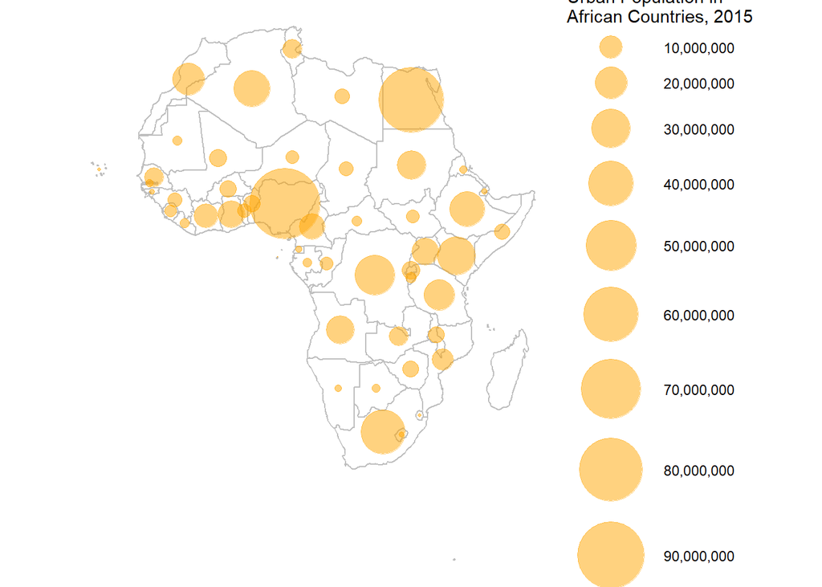

```r
urban_africa_centeroids <- urban_africa_countries %>%
  st_centroid()

ggplot(africa_countries_transformed) +
  geom_sf(fill = NA, color = "gray") +
  geom_sf(data = urban_africa_centeroids,
            aes(size = upop15),
            alpha = 0.5, color = "orange") +
  scale_size_continuous(name = "Urban Population in\nAfrican Countries, 2015",
      breaks = seq(0, 100000000, by = 10000000),
      labels = formatC(seq(0, 100000000, by = 10000000),
                       big.mark = ",", format = "f", digits = 0),
      range = c(0, 20)) +
  theme_void()
```

## Attempt at a Dorling Cartogram

I did also try a Dorling cartogram but I wasn’t able to get it to work. Maybe I will in the near future.